# Set up R and RStudio

## On PSU TLT’s RStudio Server (recommended)

1. What network are you on?
   - If on campus, make sure you are on the `psu` network.
   - If you are using RStudio remotely (off campus) you need to install and connect to VPN **FIRST**.
     - VPN installation and connection instructions for [Windows](https://ithelp.ssri.psu.edu/penn-state-vpn) and [Mac](https://ithelp.ssri.psu.edu/penn-state-vpn-mac)
2. Log in to R Studio
   - Go to: https://lat.tlt.psu.edu/home/remoteaccess/oss-web-apps/
   - Scroll down to the RStudio Server Section

[figure not shown]

   - Click on the blue box **Login to RStudio**
   - This link: https://rstudio.tlt.psu.edu/s/af233cfc78a318b9e0671/auth-sign-in may work instead of the above steps
   - Use your PSU Access Account Username and Password to sign in to RStudio.

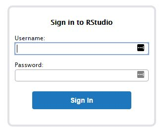

### How to Connect Github and RStudio on the TLT Server using a GitHub Access Token

#### Enter your email (used to log into R Studio) and username into RStudio

- Navigate to the Terminal Tab in R Studio Type the following in to the Command line

$ `git config --global user.email "user@psu.edu"` $ `git config --global user.name "First Last"`

#### Each person needs to have their own or project branch

First request from the Lab Manager to create your own branch and provide the Name of the Branch (e.g. firstname_lastname).

The lab manager will create this branch on the Github repository site.

#### Enter your branch into the repository in Rstudio.

- Navigate to the Terminal Tab in R Studio Type the following in to the Command line

$ `git branch -m <branchName>`

#### Create an Access Token in Git

- Follow the [Create a Personal Access Token](https://docs.github.com/en/authentication/keeping-your-account-and-data-secure/creating-a-personal-access-token) instructions.
- Be sure to copy this token into a safe place. If it is lost, one must be re-created.

#### Clone a Git Repository to RSTudio on TLT Server.

- Navigate to the GitHub project page (e.g. https://github.com/gilmore-lab/student-testbed)
- Press the button `Code`
- Copy the HTTPS link of the project by clicking the little icon to the right of the URL. The link will be something like https://github.com/gilmore-lab/student-testbed.git

[figure not shown]

- Copy this to another blank page. This will need to be altered to the following: `https://oath2:<PersonalAccessToken>@github.com/<repository>/<project>`

- The `Personal Access Token` created in Git will be used in the above location. `https://oath2:<PersonalAccessToken>@github.com/gilmore-lab/student`

#### Make changes to branch on repository.

- Ensure the branch name is listed in the Git window in R

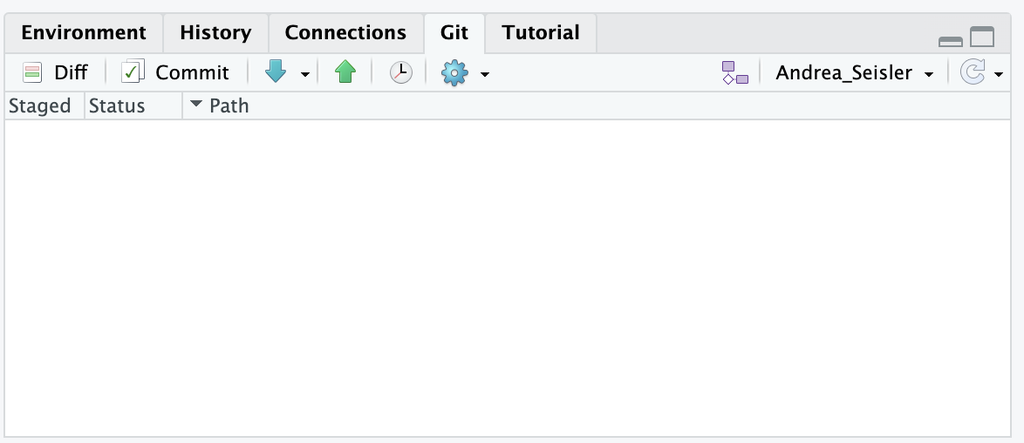

- Always run ‘Git Pull’ before changes are made - Make Changes to File - Commit changes - Run ‘Git Push’ to Your Branch on Github

- Go to `github.com/gilmorelab/<repository name>` and create a Pull request
- Notify the lab manager that a pull request is available on GitHub for `<repository name>`